# RNA-seq analysis pipeline

Jérémy Le Luyer

11 mai 2015

**Pipeline description**

1. Parallelize jobs in Colosse
   - Script generator for parallelized jobs in Colosse
2. Data trimming
   - Trimming of the RNA-seq reads (Trimmomatic)
3. Genome mapping (TopHat)
   - Indexing reference genome (Bowtie2)
   - Align reads on reference genome (TopHat)
4. Genome mapping (STAR)
   - Indexing reference genome (STAR index)
   - Align reads on reference genome (STAR)
5. Reads count table
   - Create name-sorted .bam file (Samtools)
   - Create reads count file (HTSeq)
6. Extracting DE genes (DEseq2)
   - Extract DE genes
7. Extracting DE genes (edgeR)
   - Extract DE genes
8. Fonctionnal gene annotation
   - Blast DE genes against uniprot
   - Extract Uniprot_ID for Gene Ontology association (GOminer)

*Note: Source codes of the software used here are available within the Mugqic pipeline implemented in Colosse ‘apps/mugqic_pipeline/1.2’. For more information about the tools available within Mugqic please contact: assistance@genome.ulaval.ca*

# 1. Parallelize jobs for Colosse

Colosse is specifically made for highly parallelized jobs (*i.e* 1 job /sample). In this example I will use two samples: Sample1 and Sample2. Data from HiSeq2000 for paired-ends reads give 2 files by sample, namely:

> sample1_R1.fastq.gz; sample1_R2.fastq.gz

> sample2_R1.fastq.gz; sample2_R2.fastq.gz

*Note: R1 and R2 represent left and right senses, respectively*

**First create a file ‘base_liste.txt’ containing the samples base names:**

```
> ls *fastq.gz | sed 's/R[12].fastq.gz//g'|sort -u > base_liste.txt

> cat base_liste.txt

sample1_
sample2_
```

**Then run the script below, changing ‘script_name’ by the specific script you will use:**

```
> cat generate_script.sh

for base in $(cat base_list.txt); do toEval="cat script_name_template.sh | sed 's/__BASE__/$base/g'"; eval $toEval > scripts_name_$base.sh;done
```

**This command will give two .sh files:**

```
> ls script_name*_.sh

script_name_sample1_.sh
script_name_sample2_.sh
```

**Then, simply launch the scripts in Colosse using:**

```
 > for i in $(ls script_name_*_.sh); do msub $i; done
```

*Note: repeat this for each of the scripts below to increase Colosse efficiency*

# 2. Data trimming

## Trimming (Trimmomatic)

Here we remove Illumina adapters & vectors contamination using Trimmomatic

**In /home/user_name/ in Colosse, first create a file trimmomatic_template.sh, containing:**

```
> cat trimmomatic_template.sh

#!/bin/bash
#PBS -A _user_colosse_ID_
#PBS -N trimmomatic
#PBS -o trimmomatic.out
#PBS -e trimmomatic.err
#PBS -l walltime=01:00:00
#PBS -M _user_mail_adress_
#PBS -m ea
#PBS -l nodes=1:ppn=8
#PBS -r n

module load compilers/gcc/4.8
module load apps/mugqic_pipeline/1.2
module load mugqic/java/jdk1.7.0_60
module load mugqic/trimmomatic/0.32

base=__BASE__

java -XX:ParallelGCThreads=1 -Xmx22G -cp $TRIMMOMATIC_JAR org.usadellab.trimmomatic.TrimmomaticPE \
        -phred33 \
        "$base"R1.fastq.gz \
        "$base"R2.fastq.gz \
        "$base"R1.paired.fastq.gz \
        "$base"R1.single.fastq.gz \
        "$base"R2.paired.fastq.gz \
        "$base"R2.single.fastq.gz \
        ILLUMINACLIP:/home/user_name/univec_trimmomatic.fasta:2:20:7 \
        LEADING:20 \
        TRAILING:20 \
        SLIDINGWINDOW:30:30 \
        MINLEN:60
```

*Note: univec_trimmomatic.fasta needs to be downloaded in home/user_name/ before running the script*

*Note: the parameters are quite stringent and might be modificated please visit: http://www.usadellab.org/cms/uploads/supplementary/Trimmomatic/TrimmomaticManual_V0.30.pdf*

*Note: we only keep the .paired.fastq.gz files for the next steps*

*Note: consider add an additional QC check for your trimmed reads using FASTX-toolkit: Please see http://hannonlab.cshl.edu/fastx_toolkit/*

# 3. Genome mapping (Tophat)

## Genome indexing (bowtie2)

```
> cat tophat_index_template.sh

#!/bin/bash
#PBS -A _user_colosse_ID_
#PBS -N tophat.index
#PBS -o tophat.index.out
#PBS -e tophat.index.err
#PBS -l walltime=24:00:00
#PBS -M _user_mail_adress_
#PBS -m ea
#PBS -l nodes=1:ppn=8
#PBS -r n

module load compilers/gcc/4.8  apps/mugqic_pipeline/2.1.1
module load mugqic/tophat/2.0.14
module load mugqic/bowtie2/2.2.5
module load mugqic/samtools/1.2

bowtie2-build /home/_user_name_/genome.fa genome_b2.ref
```

*Note: need to have genome.fa in /home/*user_name*/*

*Note: ideally use chr.fa + ScaffoldNotPlaced.fa files*

*Note: sequences for rainbow trout can be find here: http://www.genoscope.cns.fr/trout/data/*

*Note: allocation time ‘#PBS -l walltime=24:00:00’ should be adapted to the real needs*

**To download and uncompress for example ‘Oncorhynchus_mykiss_chr.fa.gz’ from the website in Colosse use:**

```
> wget http://www.genoscope.cns.fr/trout/data/Oncorhynchus_mykiss_chr.fa.gz
> gunzip Oncorhynchus_mykiss_chr.fa.gz
```

## Align reads on the reference genome (TopHat)

```
> cat tophat_align_template.sh

#!/bin/bash
#PBS -A _user_colosse_ID_
#PBS -N tophatAlign__BASE__
#PBS -o tophatAlign__BASE__.out
#PBS -e tophatAlign__BASE__.err
#PBS -l walltime=24:00:00
#PBS -M _user_mail_adress_
#PBS -m ea
#PBS -l nodes=1:ppn=8
#PBS -r n

base=__BASE__

module load compilers/gcc/4.8  apps/mugqic_pipeline/2.1.1
module load mugqic/tophat/2.0.14
module load mugqic/bowtie2/2.2.5
module load mugqic/samtools/1.2

tophat -o tophat_out_"$base" -G genome_annot.gff -p 8 genome_b2.ref "$base"R1.paired.fastq.gz "$base"R2.paired.fastq.gz
```

*Note: You need to download the .gff annotation file corresponding to your genome.fa*

*Note: Consider an additional mapping QC using Samstat: Please see: http://samstat.sourceforge.net/*

# 4. Genome mapping (STAR)

## Genome indexing (STAR index)

**create STAR_index_template.sh:**

```
> cat STAR_index_template.sh

#!/bin/bash
#PBS -A _user_Colosse_ID_
#PBS -N STAR_index
#PBS -o STAR_index.out
#PBS -e STAR_index.err
#PBS -l walltime=24:00:00
#PBS -M _user_mail_adress_
#PBS -m ea
#PBS -l nodes=1:ppn=8
#PBS -r n

module load compilers/gcc/4.8  apps/mugqic_pipeline/2.1.1
module load mugqic/blat/36
module load mugqic/star/2.4.0k

mkdir /path/to/genomeDirChr

STAR --runThreadN 1 \
  --runMode genomeGenerate \
  --genomeDir /path/to/genomeDirChr \
    --genomeFastaFiles /path/to/genome.fa \
    --sjdbOverhang 99 \
    --genomeChrBinNbits 10 \
    --limitGenomeGenerateRAM 20000000000
```

*Note: .gff is not included in the indexing step with STAR*

*Note: genomeDirChr needs to be empty prior to launch STAR index*

## Align of reference genome (STAR)

**Create STAR_align_template.sh:**

```
> cat STAR_align_template.sh

#!/bin/bash
#PBS -A _user_Colosse_ID_
#PBS -N STAR_align__BASE__
#PBS -o STAR_align__BASE__.out
#PBS -e STAR_align__BASE__.err
#PBS -l walltime=24:00:00
#PBS -M _user_mail_adress_
#PBS -m ea
#PBS -l nodes=1:ppn=8
#PBS -r n

module load compilers/gcc/4.8  apps/mugqic_pipeline/2.1.1
module load mugqic/blat/36
module load mugqic/star/2.4.0k

base=__BASE__

STAR --runThreadN 8 \
  --genomeDir genomeDirChr \
    --readFilesIn /path/to/"$base"R1.paired.fastq.gz /path/to/"$base"R2.paired.fastq.gz \
    --readFilesCommand zcat \
    --sjdbGTFfile /path/to/genome_annot.gff \
    --outFileNamePrefix STAR_alignChr_"$base"
```

*Note: .gff is used at this step*

# 5. Reads count tables

## Sort .bam file by names

Using sammtools to create names-sorted .bam files to further use in HTSeq.

**Create samtoolsSort_names_template.sh:**

```
> cat samtoolsSort_names_template.sh

#!/bin/bash
#PBS -A _user_colosse_ID_
#PBS -N samtoolsSort__BASE__
#PBS -o samtoolsSort__BASE__.out
#PBS -e samtoolsSort__BASE__.err
#PBS -l walltime=06:00:00
#PBS -M _user_mail_adress_
#PBS -m ea
#PBS -l nodes=1:ppn=8
#PBS -r n

module load compilers/gcc/4.8  apps/mugqic_pipeline/2.1.1
module load mugqic/tophat/2.0.14
module load mugqic/bowtie2/2.2.5
module load mugqic/samtools/1.2

base=__BASE__

samtools sort -n tophat_out_"$base"/accepted_hits.bam tophat_out_"$base"/tophat_"$base"NamesSorted
```

*Note: Despite HTSeq ‘normally’ using also position-sorted .bam files, bugs still remain and names-sorted are thus prefered*

## Create reads-count files

**Create HTseq-template.sh file:**

```
> cat HTseq_template.sh

#!/bin/bash
#PBS -A _user_colosse_ID_
#PBS -N HTseq-countmRNA__BASE__
#PBS -o HTseq-countmRNA__BASE__.out
#PBS -e HTseq-countmRNA__BASE__.err
#PBS -l walltime=24:00:00
#PBS -M _user_mail_adress_
#PBS -m ea
#PBS -l nodes=1:ppn=8
#PBS -r n

module load compilers/gcc/4.8  apps/mugqic_pipeline/2.1.1
module load mugqic/tophat/2.0.14
module load mugqic/bowtie2/2.2.5
module load mugqic/samtools/1.2

base=__BASE__

HTSeq-0.6.1/build/scripts-2.7/htseq-count -f bam -s no -t mRNA -i mRNA tophat_out_"$base"/tophat_"$base"NamesSorted.bam genome_annot.gff >> output_mRNA_tophat_HTseq-count_"$base".txt
```

*Note: -s no for non-stranded; -t (for feature) ideally ‘exon’ but here changed for ‘mRNA’; -i (id_gene) changed for ‘mRNA’*

*Note: HTSeq not implemented in mugqic pipeline and needs to be installed locally in /home/*user_name*/. Please see for installation and source code: http://www-huber.embl.de/users/anders/HTSeq/doc/install.html*

The output files from HTseq-count should look like:

```
> head -n 5 output_mRNA_tophat_HTseq-count_sample1.txt

GSONMT00000001001  53
GSONMT00000002001   59
GSONMT00000003001   219
GSONMT00000004001   0
GSONMT00000006001   62
```

*Note: Column$1: Gene_id; column$2: reads count*

# 6. Extract DE genes (Deseq2)

*Note that pipeline was not implemented for Colosse (in progress) and need to be launched locally in* user* computer*

**To import data from Colosse in *user* machine (here for example importing ‘output_mRNA_tophat_HTseq-count_sample1.txt’ to ‘/Users/jeremyleluyer/Desktop/essai_HTseq/tophat’)

```
> rsync -avzP _user_name_@colosse.calculquebec.ca:/home/_user_name/ /Users/jeremyleluyer/Desktop/essai_HTseq/tophat/.
```

This is a simple pipeline adapted from http://dwheelerau.com/2014/02/17/how-to-use-deseq2-to-analyse-rnaseq-data/

This pipeline serves for comparing DE gene expression from RNA-seq (2 conditions x 3) replicates based on a reads-count matrix from HTseq-count

*Note: The file names might have changed*

**First import the DESeq2 library from Bioconductor**

```
source("http://bioconductor.org/biocLite.R")
biocLite("DESeq2")
```

**Load the library**

```r
library('DESeq2')
```

**Import the data and create the dataset**

```r
directory<-"/Users/jeremyleluyer/Desktop/essai_HTseq/tophat"
sampleFiles <- grep("s27",list.files(directory),value=TRUE)
```

Then check the sampleFiles and the order of the file is correct

```r
sampleFiles
```

```
## [1] "s27def.s27b1n2.txt"    "s27def.s27b1n7.txt"    "s27def.s27b3n6.txt"
## [4] "s27recov.s27b11n2.txt" "s27recov.s27b7n4.txt"  "s27recov.s27b9n6.txt"
```

```r
sampleCondition<-c("def","def","def","recov","recov","recov")
sampleTable<-data.frame(sampleName=sampleFiles, fileName=sampleFiles, condition=sampleCondition)
ddsHTSeq<-DESeqDataSetFromHTSeqCount(sampleTable=sampleTable, directory=directory, design=~condition)
```

```r
colData(ddsHTSeq)$condition<-factor(colData(ddsHTSeq)$condition, levels=c("def","recov"))
```

**Time to make the comparison ! Note that alpha indicates the FDR (pAdj value *i.e* the correction for multiple tests)**

```r
dds<-DESeq(ddsHTSeq)
res<-results(dds,alpha = 0.05)
res<-res[order(res$padj),]
summary(res, alpha =0.05)
```

```
##
## out of 44187 with nonzero total read count
## adjusted p-value < 0.05
## LFC > 0 (up)     : 123, 0.28%
## LFC < 0 (down)   : 331, 0.75%
## outliers [1]     : 51, 0.12%
## low counts [2]   : 11010, 25%
## (mean count < 6.8)
## [1] see 'cooksCutoff' argument of ?results
## [2] see 'independentFiltering' argument of ?results
```

**Do the MA ploting (for those who want it !)**

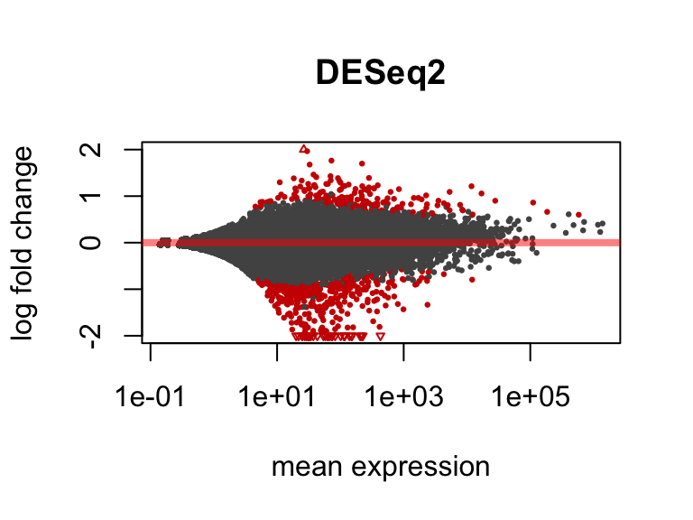

```r
plotMA(dds,ylim=c(-2,2),main="DESeq2")
```

Print the .png in a separate file use (optional)

```
dev.copy(png,"deseq2_MAplot_tophat.png")
dev.off()
```

**Save the table in a .csv file for futher use (Blast)**

```r
mcols(res,use.names=TRUE)
```

```
## DataFrame with 6 rows and 2 columns
##                        type                                    description
##                 <character>                                    <character>
## baseMean       intermediate      mean of normalized counts for all samples
## log2FoldChange      results log2 fold change (MAP): condition recov vs def
## lfcSE               results         standard error: condition recov vs def
## stat                results         Wald statistic: condition recov vs def
## pvalue              results      Wald test p-value: condition recov vs def
## padj                results                           BH adjusted p-values
```

```r
write.csv(as.data.frame(res),file="def_recov_deseq2_tophat.csv")
```

**Transform the data:**

```r
rld <- rlogTransformation(dds, blind=TRUE)
vsd <- varianceStabilizingTransformation(dds, blind=TRUE)
```

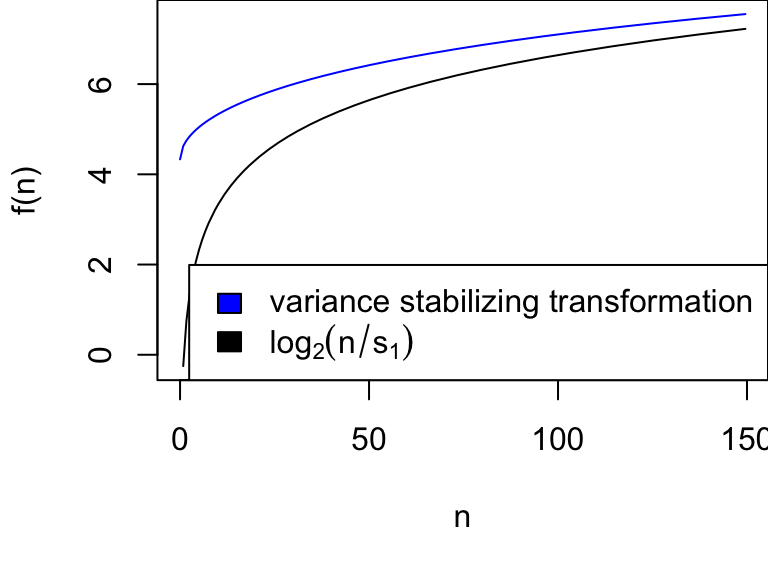

```r
par(mai=ifelse(1:4 <= 2, par("mai"), 0))
px     <- counts(dds)[,1] / sizeFactors(dds)[1]
ord    <- order(px)
ord    <- ord[px[ord] < 150]
ord    <- ord[seq(1, length(ord), length=50)]
last   <- ord[length(ord)]
vstcol <- c("blue", "black")
matplot(px[ord], cbind(assay(vsd)[, 1], log2(px))[ord, ], type="l", lty=1, col=vstcol, xlab="n", ylab="f(n)")
legend("bottomright", legend = c(expression("variance stabilizing transformation"), expression(log[2](n/s[1]))), fill=vstcol)
```

**Load required libraries for ploting**

```r
library("vsn")
library("RColorBrewer")
library("gplots")
```

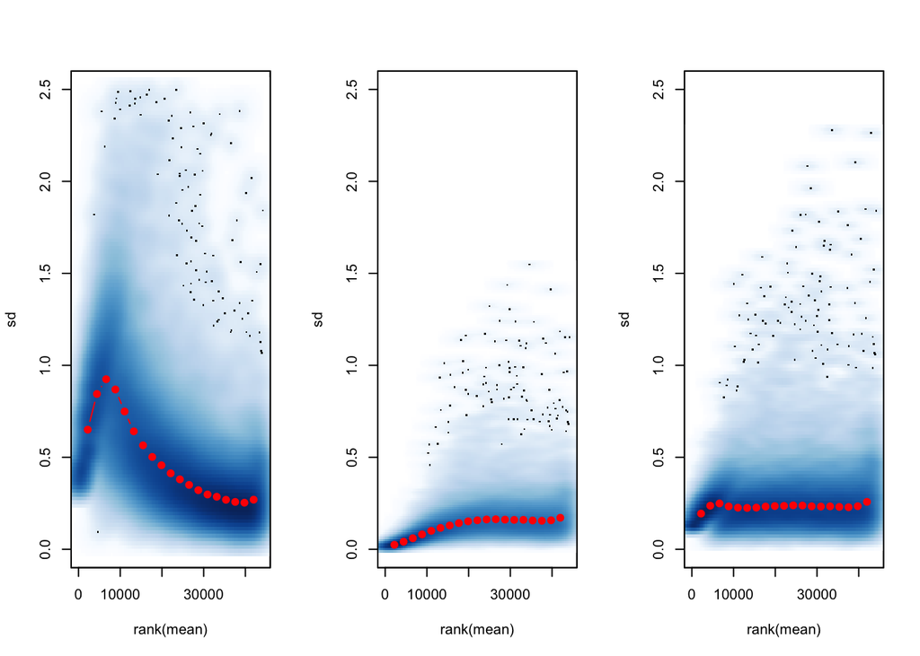

```r
par(mfrow=c(1,3))
notAllZero <- (rowSums(counts(dds))>0)
meanSdPlot(log2(counts(dds,normalized=TRUE)[notAllZero,] + 1), ylim = c(0,2.5))
meanSdPlot(assay(rld[notAllZero,]), ylim = c(0,2.5))
meanSdPlot(assay(vsd[notAllZero,]), ylim = c(0,2.5))
```

**Heatmap**

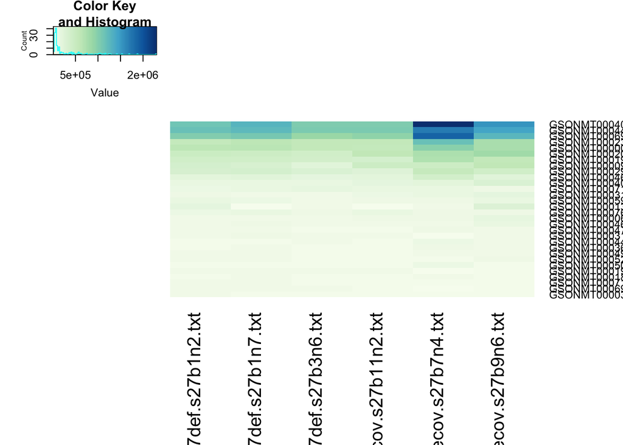

```r
select <- order(rowMeans(counts(dds,normalized=TRUE)),decreasing=TRUE)[1:30]
hmcol <- colorRampPalette(brewer.pal(9, "GnBu"))(100)
heatmap.2(counts(dds,normalized=TRUE)[select,], col = hmcol,
          Rowv = FALSE, Colv = FALSE, scale="none",
          dendrogram="none", trace="none", margin=c(10,6))
```

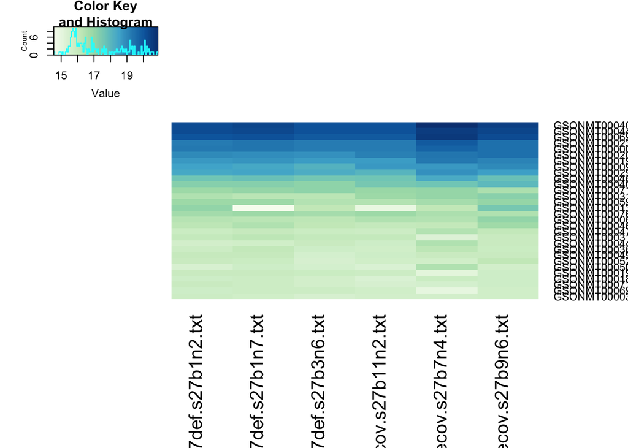

```r
heatmap.2(assay(rld)[select,], col = hmcol,
          Rowv = FALSE, Colv = FALSE, scale="none",
          dendrogram="none", trace="none", margin=c(10, 6))
```

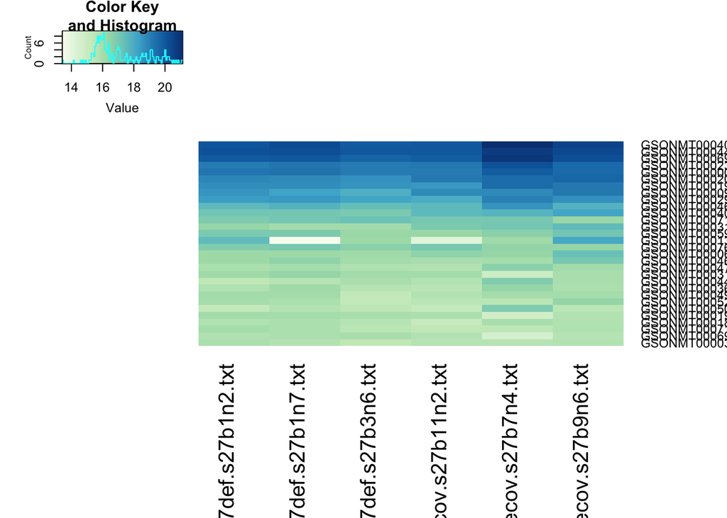

```r
heatmap.2(assay(vsd)[select,], col = hmcol,
          Rowv = FALSE, Colv = FALSE, scale="none",
          dendrogram="none", trace="none", margin=c(10, 6))
```

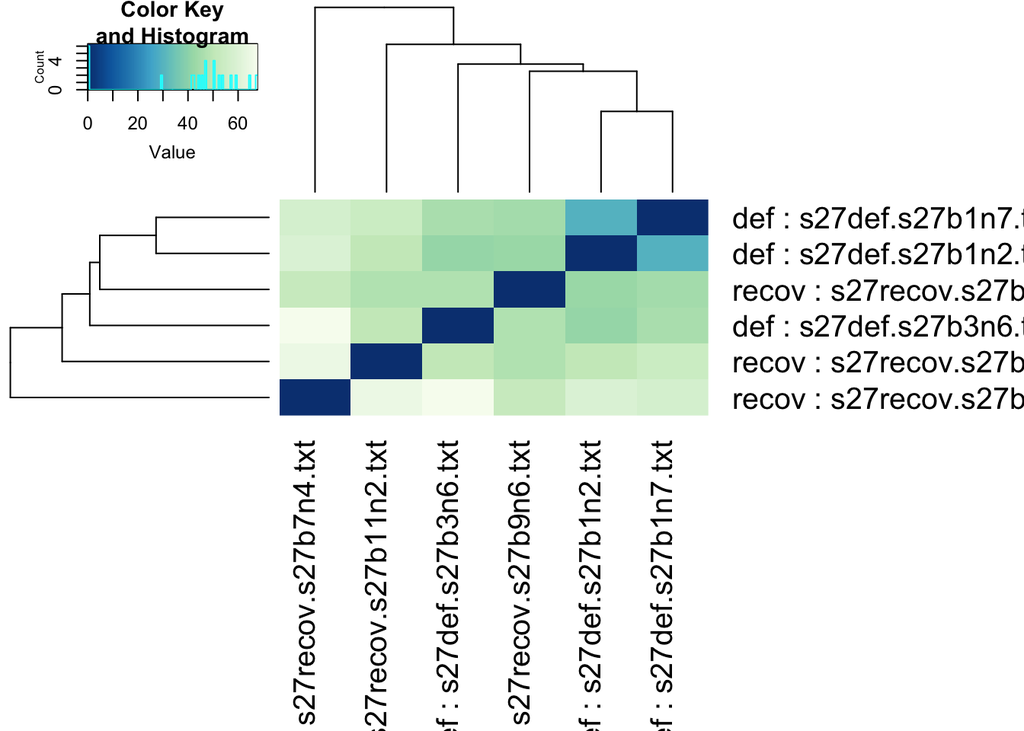

```r
distsRL <- dist(t(assay(rld)))
mat <- as.matrix(distsRL)
rownames(mat) <- colnames(mat) <- with(colData(dds),
                                       paste(condition,sampleFiles , sep=" : "))
hc <- hclust(distsRL)
heatmap.2(mat, Rowv=as.dendrogram(hc),
          symm=TRUE, trace="none",
          col = rev(hmcol), margin=c(13, 13))
```

**Plot a PCA**

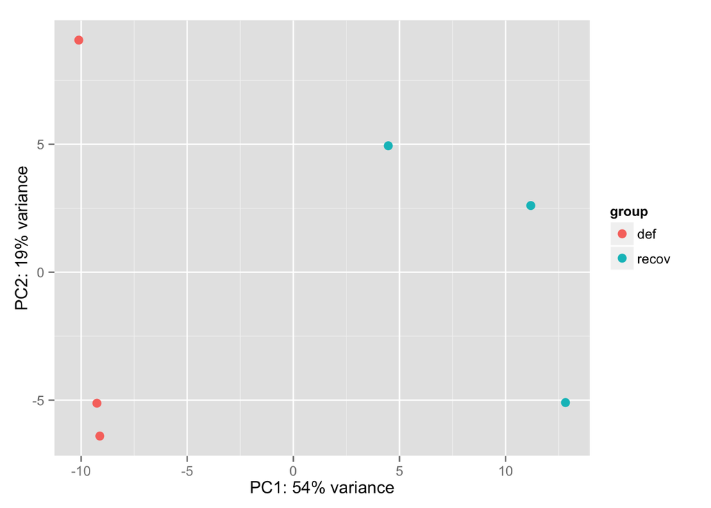

```r
print(plotPCA(rld, intgroup=c("condition")))
```